# A Brief Introduction to RNA-Seq

RAdelaide 2024

Author

Affiliation

Dr Stevie Pederson

Black Ochre Data Labs  
Telethon Kids Institute

Published

July 11, 2024

# Transcriptomic Analysis

## Transcriptomic Analysis

- High-throughput transcriptomic analysis took off ~25 years ago
  - Followed the release of the the human genome very rapidly
- Microarrays enabled transcriptome-wide profiling of gene expression
  - Probes were designed for each targeted gene
- The Bioconductor package `limma` was first released in 2004 (Smyth 2004)
  - Still heavily used and maintained

. . .

- How does gene expression change across two or more groups
  - Control vs Treatment
- Represents an abundance analysis
- Relies on many, many cells pooled together

## RNA-Seq

. . .

- Bulk RNA-Seq built on methods established for microarrays
  - New statistical models became quickly established
- Focussed on *gene-level* analysis
  - Now relatively mature

## RNA-Seq

- Bulk RNA-Seq at the *transcript level* is still relatively immature
- Single-Cell RNA-Seq now has a degree of maturity
  - Cell trajectory analysis also moving rapidly
- Spatial Transcriptomics is an emerging and rapidly developing technology
  - Also includes imaging technologies

. . .

- Today we’ll focus on gene-level, bulk RNA-Seq analysis
  - Learning file types, packages, object classes, methods
  - Also visualisation strategies

## Transcriptomes

- Genes are considered as genomic regions transcribed into RNA
- The complete region (i.e. locus) is transcribed
  - Introns are *spliced out* $\implies$ mature transcripts

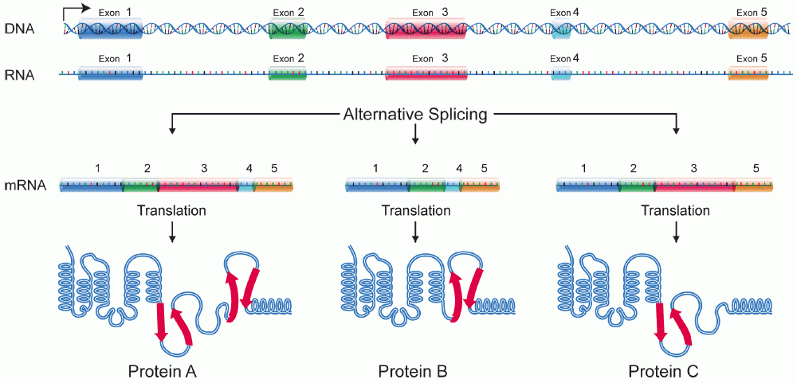

Image courtesy of National Human Genome Research Institute

Historically genes were considered to be units of heritability The idea of a transcribed locus is a modern concept

## The Basics of Bulk RNA-Sequencing

1. Intact RNA is extracted from a sample
   - Tens of thousands of cells are lysed
   - May contain RNA from different cell types
2. RNA is fragmented into 250-500bp fragments
   - Lose short transcripts $\implies$ long transcripts broken into pieces

## The Basics of Bulk RNA-Sequencing

3. Prepared for sequencing
   - Converted to cDNA
   - Sequencing adapters added to all fragments
   - PCR amplification
4. Sequenced from both directions (paired end sequencing)
   - Commonly 50m reads/sample

## The Basics of Bulk RNA-Sequencing

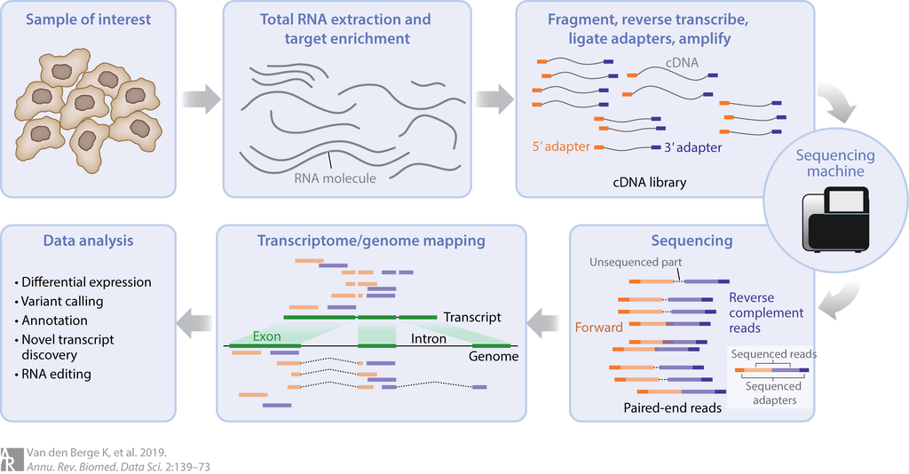

## Sequencing Technology

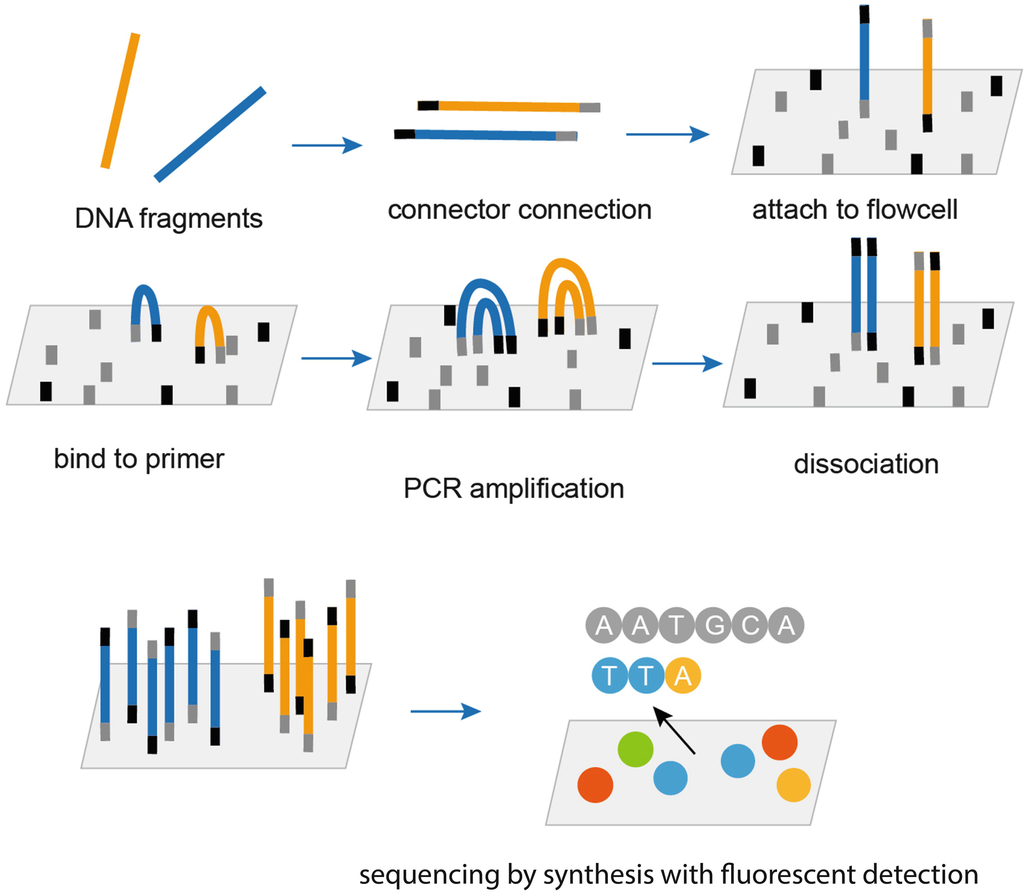

Wang, M. (2021). Next-Generation Sequencing (NGS). In: Pan, S., Tang, J. (eds) Clinical Molecular Diagnostics. Springer, Singapore. https://doi.org/10.1007/978-981-16-1037-0_23

- The prepared library is added to a flowcell
- Hopefully the dilution spreads molecules sparsely & evenly

## Fastq Files

- The output from sequencing is a `fastq` file
  - Plain text file
- Commonly 30-50 million reads in each file
  - Each read takes 4 lines
  - 50m read x 4 lines = 200m lines
- Often compressed with `fq.gz` suffix
- Almost never parsed into `R`

## Fastq Files

- If fragments are sequenced from one end only: *single-end reads*
- If sequenced from both ends: *paired-end reads*
- Both provided in separate files
  - `{prefix}_R1.fq.gz` + `{prefix}_R2.fq.gz`
  - Files match exactly
- Paired reads still represent a single fragment
  - More sequence information $\implies$ more confident alignment

## Fastq Files

1. Read header starts with `@`
2. Sequence
3. `+`
4. Quality scores

. . .

```
@SRR001666.1 071112_SLXA-EAS1_s_7:5:1:817:345 length=72
GGGTGATGGCCGCTGCCGATGGCGTCAAATCCCACCAAGTTACCCTTAACAACTTAAGGGTTTTCAAATAGA
+
IIIIIIIIIIIIIIIIIIIIIIIIIIIIII9IG9ICIIIIIIIIIIIIIIIIIIIIDIIIIIII>IIIIII/
@SRR001666.2 071112_SLXA-EAS1_s_7:5:1:801:338 length=72
GTTCAGGGATACGACGTTTGTATTTTAAGAATCTGAAGCAGAAGTCGATGATAATACGCGTCGTTTTATCAT
+
IIIIIIIIIIIIIIIIIIIIIIIIIIIIIIII6IBIIIIIIIIIIIIIIIIIIIIIIIGII>IIIII-I)8I
```

- We rarely parse these into `R`

## Workflow Outline

1. QC and Read Trimming (optional) 😇
2. Align reads to the reference genome 😀
3. Count how many reads for each gene 😐
4. Statistical (DGE) analysis 😕
5. Enrichment analysis 😰
6. Biological Interpretation 😱
- Trimming, aligning and counting on an HPC
- QC analysis, Statistical and enrichment analysis in R
- Interpretation with domain experts

Counting is implemented in R but I generally don’t

## Alternative Approaches

- Alternative methods align to transcript sequences NOT the genome
- These alignments are not spliced
- Most reads align to multiple transcripts
  - With genomic alignments usually a single alignment

. . .

- Transcript-level analysis is a newly solved problem (Baldoni et al. 2024)
- Downstream analysis using transcripts is challenging
  - Genes mapped to functions & pathways *NOT* transcripts

## Data Pre-Processing

- A ‘read’ is the total signal from an entire cluster of molecules
- If errors occur during cluster formation:
  - Molecules get ‘out-of-sync’
  - Actual sequence becomes uncertain
  - Low quality scores assigned
- Most people discard low quality reads
- Adapter sequences at either end can also be removed
  - Derive from short RNA fragments

## Data Pre-Processing

- Overall summaries of library quality can be obtained $\implies$ `FastQC`
- Multiple tools to perform Pre-processing
  - `cutadapt`, `AdapterRemoval`, `trimmomatic`, `TrimGalore` etc
  - Potentially problematic reads or sequences removed
- `fastp` combines QC reports with read trimming

## Data Pre-Processing

- `FastQC`, `fastp`, `cutadapt` all return reports after running
  - Are run on a single library (i.e. sample) at a time
- [`MultiQC`](https://multiqc.info) is an excellent standalone tool for combining all reports
- `ngsReports` is the “go-to” Bioconductor package for this
  - Can also import alignment summaries + many others

Not going to go into ngsReports today but I use regularly in my QC workflows

## Alignment

- Pre-processed reads are aligned to a genome
- All aligners based on Burrows-Wheeler Transform
  - Comp. Sci algorithm for fast searching
  - Requires the *creation of an index* which is searched
- Most common aligners are `STAR`, `hisat2` or `bowtie2`
  - All splice-aware
  - GTF used during building of the index
- Requires an HPC & scripting skills

## Bam Files

- After alignment to the reference $\implies$ `bam` files produced
- Usually contain millions of alignments
- Each read now occupies a single line with 11 tab-separated fields

| Column | Field | Description |
| --- | --- | --- |
| 1 | `QNAME` | The original FastQ header line |
| 2 | `FLAG` | Information regarding pairing, primary alignment, duplicate status, unmapped etc |
| 3 | `RNAME` | Reference sequence name (e.g. chr1) |
| 4 | `POS` | Left-most co-ordinate in the alignment |
| 5 | `MAPQ` | Mapping quality score |
| 6 | `CIGAR` | Code summarising exact matches, insertions, deletions etc. |
| 7 | `RNEXT` | Reference sequence the mate aligned to |
| 8 | `PNEXT` | Left-most co-ordinate the mate aligned to |
| 9 | `TLEN` | Read length |
| 10 | `SEQ` | The original read sequence |
| 11 | `QUAL` | The read quality scores |

SAM files are plain text whilst BAM are compressed to save storage

## Bam Files

- 12th (optional) column often contains tags
  - `NH:i:1` indicates this read aligned only once
  - `AS:i:290` the actual alignment score produced by the aligner
  - `NM:i:2` two edits are required to perfectly match the reference

. . .

- Reads can align to multiple locations
  - Sometimes more alignments than reads
- Rarely, only one read in a pair may align
- Generally view small subsets of data using `samtools` in `bash`

## Bam Files

- The Bioconductor interface to `bam` files is `Rsamtools`
- We define `BamFile` or `BamFileList` objects
- Are a simple connection to the file (including checks)
- We don’t load anything when created
  - Instead define specific subsets to load for a specific task

## Bam Files

- When loading a subset of reads set `ScanBamParam()`
- Enables loading alignments:
  - from specific ranges (using `GRanges`)
  - with specific tags or flags
- Controls which columns are returned

. . .

- Sequences loaded as `DNAStringSet`s
- Alignment co-ordinates as `GRanges` objects

## Read Counting

- Most assigning of reads to genes is performed by external tools
- Gene, Transcript & Exon co-ordinates passed in a GTF
  - Aligned Reads overlapping an exon/transcript/gene are counted

. . .

- Produces flat (i.e. tsv) files $\implies$ count once & load each time you start
- Today’s count data produced using `featureCounts` from the `Subread` tool
  - Other tools are `RSEM`, `htseq`

## Read Counting

- Counting can be performed in `R`:
  - `Rsubread` or `GenomicAlignments`
- Should still only be performed once and saved as a standalone file
  - Would avoid doing at the start of every R script

## Trancriptomic Pseudo-Aligners

- `salmon` and `kallisto` perform pseudo-alignments to the transcriptome (i.e. *not* the genome)
- Don’t produce `bam` files $\implies$ only transcript-level counts
- Transcript-level counts have explicit uncertainty due to multi-mapping
  - Can now be modelled confidently
- Can be simply summed to obtain gene-level counts
- Becoming increasingly popular

## Reference Annotations

- Reference *genomes* are relatively stable over many years
- Available from multiple sources
  - Inconsistent use of the “chr” prefix
  - Inconsistency in “chrM” or “chrMT”
  - Some variability in scaffolds

## Reference Annotations

- Annotation sets are updated multiple times every year
  - Gencode, Ensembl, UCSC
  - Usually minor changes
- Not important for genomic alignment
- Very important for read counting & transcriptomic alignment
- Changes appear as genes move from predicted to verified
- Prediction algorithms also change

## Reference Annotations

- The latest Gencode set of annotations (Release 46, May 2024)
- 63,086 Genes
  - 19,411 protein coding
  - Remainder are lncRNA, pseudogenes etc
- 254,070 Transcripts
  - 89,581 protein coding
  - Remainder are NMD, lncRNA etc
- Shortest annotated (spliced) transcript is 8nt $\implies$ longest is 350,375nt

Checking Gencode v41 there were 251,295 transcripts and 61,906 genes

## References

Baldoni, Pedro L, Yunshun Chen, Soroor Hediyeh-Zadeh, Yang Liao, Xueyi Dong, Matthew E Ritchie, Wei Shi, and Gordon K Smyth. 2024. “Dividing Out Quantification Uncertainty Allows Efficient Assessment of Differential Transcript Expression with edgeR.” *Nucleic Acids Res.* 52 (3): e13.

Smyth, Gordon K. 2004. “Linear Models and Empirical Bayes Methods for Assessing Differential Expression in Microarray Experiments.” *Stat. Appl. Genet. Mol. Biol.* 3 (February): Article3.